# Final Project

You and your team of data scientists were hired by a company to gain insights on the dataset in your chosen prompt.

1. Perform any necessary data pre-processing and cleaning, and document your steps. Depending on the prompt you selected, this may involve transforming variables, creating new variables, and merging data frames. In particular, you may need to make some decisions on how to handle missing data, such as removing rows or columns with a significant amount of missing observations, creating an “unknown” category, or replacing/imputing the missing values. You do not need to develop a rigorous process or cite references, but please briefly justify your choices.

**[Answers written as comments]**

2. Make and interpret 4-10 visualizations to help you understand the relationships between the variables in your dataset. We highly encourage you to explore the data on your own, but when preparing your response to this question, please be parsimonious in your plots and select visualizations that help you tell a story about the data. If you need to make additional plots to support your responses to the other questions (e.g. to motivate data cleaning or modeling choices), that’s fine.

**[Answers written as comments]**

3. Build any 2 machine learning models that use your choice of covariates to predict the given outcome variable. Explain why you chose those covariates and interpret the model performances.

**[Answers written in Section 3.1 and 3.3.2]**

4. The company stakeholders want to know what decision they should make on their stated goal/question. Based on your analysis, make recommendations for a non-technical audience

5. Any additional information that might be useful to collect/have? Other open-ended/non-coding question(s)?

### NHANES (2013-2014)

The National Health and Nutrition Examination Survey (NHANES) assesses the health and nutritional status of adults and children in the United States. The `covariate_df` data frame in the `covariate_df.rData` file contains the demographic, examination, diet, and lab data from [NHANES 2013-2014](https://www.kaggle.com/datasets/cdc/national-health-and-nutrition-examination-survey). You can peruse the dictionaries for the variables on the CDC website: [demographics](https://wwwn.cdc.gov/Nchs/Nhanes/Search/variablelist.aspx?Component=Demographics&CycleBeginYear=2013), [examinations](https://wwwn.cdc.gov/Nchs/Nhanes/Search/variablelist.aspx?Component=Examination&CycleBeginYear=2013), [diet](https://wwwn.cdc.gov/Nchs/Nhanes/Search/variablelist.aspx?Component=Dietary&CycleBeginYear=2013), and [lab](https://wwwn.cdc.gov/Nchs/Nhanes/Search/variablelist.aspx?Component=Laboratory&CycleBeginYear=2013). Your goal is to use these covariates to predict the occurrence of diabetes, cancer, heart attack, stroke, OR depression. The company wants you to recommend a predictive model and identify key variables that appear to be associated with the outcome disease.

As part of data processing, choose ONE of the five diseases and merge the corresponding variable from the `questionnaire.csv` dataset with `covariate_df`. This disease is the outcome that your model should predict. The relevant variable names in `questionnaire.csv` are: DIQ010 (diabetes), MCQ220 (cancer), MCQ160E (heart attack), MCQ160F (stroke), and DPQ020 (depression). (You can view the entire questionnaire dictionary [here](https://wwwn.cdc.gov/Nchs/Nhanes/Search/variablelist.aspx?Component=Questionnaire&CycleBeginYear=2013).) For each disease variable, you can take `1` to be affected, `2` to be unaffected, and all other numeric values to be unknown/ignored.

```r
#####  Load library and data set
library(tidyverse)
library(caret)
library(e1071)
library(corrplot)
library(dplyr)
library(ggplot2)
library(tidyr)
library(class)
library(caret)
library(pROC)
library(randomForest)
library(rpart)
library(forcats)
library(viridis)
library(rpart.plot)

questionnaire <- read.csv("questionnaire.csv")
load('covariate_df.rData')
df <- questionnaire %>% inner_join(covariate_df,
                                  by = join_by(SEQN))
```

1. Data Cleaning

```r
##### Data Cleaning

#Only including adults 20 years and older##

###Outcome###
# Diabetes status
final_df <- data.frame(matrix(ncol = 0, nrow = nrow(df)))
final_df$DIQ010 <- ifelse(df$DIQ010 == 2, 0,
                    ifelse(df$DIQ010 == 1, 1,
                           NA))

###Variables###

##NHANES 2013-2014 Demographics Variable List##
# gender of participants
final_df$RIAGENDR <- ifelse(df$RIAGENDR == 1, "male",
                      ifelse(df$RIAGENDR == 2, "female",
                             NA))

# age of participants (keep as continuous >= 20)
final_df$RIDAGEYR <- ifelse(df$RIDAGEYR >= 20, df$RIDAGEYR, NA)

# highest grade or level of school
final_df$DMDEDUC <- ifelse(df$DMDEDUC2 == 1, "Less than 9th grade",
                           ifelse(df$DMDEDUC2 == 2, "9th to 11th grade",
                                  ifelse(df$DMDEDUC2 == 3, "High school graduate/GED",
                                         ifelse(df$DMDEDUC2 == 4, "Some college",
                                                ifelse(df$DMDEDUC2 == 5, "College graduate or above",
                                                       NA)))))


##NHANES 2013-2014 Examination Variable List##
# diastolic blood pressure, average of the four readings, ignore NA in one participant if other readings are valid
final_df$BPXDI <- rowMeans(df[, c("BPXDI1", "BPXDI2", "BPXDI3", "BPXDI4")], na.rm = TRUE)

# systolic blood pressure, average of the four readings, ignore NA in one participant if other readings are valid
final_df$BPXSY <- rowMeans(df[, c("BPXSY1", "BPXSY2", "BPXSY3", "BPXSY4")], na.rm = TRUE)

# BMI (keep as original)
final_df$BMXBMI <- df$BMXBMI

# waist circumference (keep as original)
final_df$BMXWAIST <- df$BMXWAIST


##NHANES 2013-2014 Dietary Variable List##
# Energy kcal (keep as original)
final_df$DR1TKCAL <- df$DR1TKCAL

# Protein gm (keep as original)
final_df$DR1TPROT <- df$DR1TPROT

# Fat gm (keep as original)
final_df$DR1TTFAT <- df$DR1TTFAT

# Carb gm (keep as original)
final_df$DR1TCARB <- df$DR1TCARB

# Fiber gm (keep as original)
final_df$DR1TFIBE <- df$DR1TFIBE

# Sugar gm (keep as original)
final_df$DR1TSUGR <- df$DR1TSUGR

# Sodium mg (keep as original)
final_df$DR1TSODI <- df$DR1TSODI

# Alcohol gm (keep as original)
final_df$DR1TALCO <- df$DR1TALCO

# Caffeine mg (keep as original)
final_df$DR1TCAFF <- df$DR1TCAFF


##NHANES 2013-2014 Laboratory Variable List##
# Total cholesterol mg/dL (keep as original)
final_df$LBXTC <- df$LBXTC

# Direct HDL-cholesterol mmol/L (keep as original)
final_df$LBDHDDSI <- df$LBDHDDSI

# Insulin pmol/L (keep as original)
final_df$LBDINSI <- df$LBDINSI


###Handling missing data###
# Delete rows with NA values
final_df <- na.omit(final_df)

###Check number of cases###
sum(final_df$DIQ010)
```

```
## [1] 242
```

```r
# 242 cases
```

2. Visualization

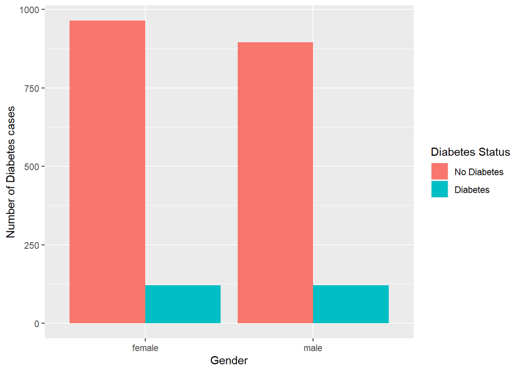

```r
##  Visualization

RIAGENDRplot <- final_df %>% group_by(RIAGENDR, DIQ010) %>% summarize("count"=n(), .groups = "drop") %>% ggplot(aes(RIAGENDR, count))+ geom_col(aes(fill = as.factor(DIQ010)), position="dodge") + labs(x="Gender", y="Number of Diabetes cases")+ scale_fill_discrete(name="Diabetes Status", labels = c("No Diabetes", "Diabetes"))
RIAGENDRplot
```